# The Mustard Seed

by Kameron York

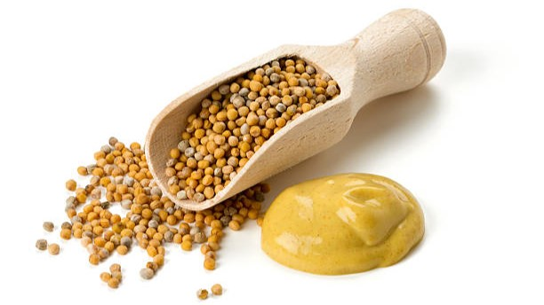

#### Reference:

[Matthew 13:31-32](https://www.churchofjesuschrist.org/study/scriptures/nt/matt/13?lang=eng&id=31-32#p31)  
[Mark 4:30-32](https://www.churchofjesuschrist.org/study/scriptures/nt/mark/4?lang=eng&id=30-32#p30)  
[Luke 13:18-19](https://www.churchofjesuschrist.org/study/scriptures/nt/luke/13?lang=eng&id=18-19#p18)

#### What is the Parable of the Mustard Seed about?

A mustard seed is an incredibly small seed that grows into the mustard plant. In this parable Jesus tells the story of a man who sowed a mustard seed in his field. The seed then grew to become a tree big enough for birds to lodge in it. The size comparison is main focus of the story. Jesus highlights how small the seed begins, and then highlights how big the resulting tree becomes.

The New Testament Institute manual says this, “When the Church was restored in 1830, it was like a tiny mustard seed. Since then it has grown until its “branches” are found in almost every nation on earth, and its members find in them a spiritual “home” and protection from the world. The Savior used the parable of the mustard seed to teach that His Church would grow from a small beginning into a very large organization.” From small beginnings come things that are great!

#### What are the Symbols in the Parable of the Mustard Seed?

**The Mustard Seed and the Tree** represent the Church of Jesus Christ. Starting small and growing to be a safe haven from the world. **The Man** represents the Savior. **The Field** represents the world. **The Birds of the Air** represents the members of Christ’s Church.

#### What Can We Learn from the Parable of the Mustard Seed

The Church of Jesus Christ is meant to be a protection from the world. In the parable the birds, “…lodge under the shadow of it.” [(Mark 4:32)](https://www.churchofjesuschrist.org/study/scriptures/nt/mark/4?lang=eng&id=32#p32). We can find the same refuge when we come unto Christ and participate in His church. We can also learn that the Church came from small beginnings, and is promised to continue growing until it has become the “…greater than all…” [(Mark 4:32)](https://www.churchofjesuschrist.org/study/scriptures/nt/mark/4?lang=eng&id=32#p32).

[output not shown]